# Exploring Transportation and Air Quality in Washington, DC

Intro to Data Science Final Project

Author

Kelly Primrose and Diana Schoder

## Background

Transportation can be a [source](https://storymaps.arcgis.com/stories/79a80bb4a7074b6989f94a4a5b154675) of air pollution, but it can also be a solution to poor air quality. For example, shifting people from car usage to walking and public transit has the potential to reduce carbon emissions, mitigate pollution-induced respiratory illness, and more. To target policy interventions in DC, it is important to know exactly what types of transportation patterns are contributing most to air pollution.

Our analysis uses unsupervised machine learning to create clusters of DC census tracts based on their transportation patterns. We use geospatial analysis to explore what is driving these clusters, which informs our “transportation typologies.” We then run three regressions to better understand the associations between these typologies and particulate matter (PM 2.5).

We then do a deeper dive into air quality in DC, using data from five air monitors. Although we only have tract-level data for PM 2.5–which makes it our primary variable of interest when examining transportation throughout the district–our exploration of the air monitors indicates that future analyses would benefit from data on other pollutants at the tract level. This portion of the analysis demonstrates that the variation in air quality is not only spatial (across tracts) but also temporal, varying with days of the week and months. We end with a decision tree that categorizes observations from the air monitors and provide recommendations on how to make this tool even more useful given everything we have discovered in our analysis.

For more info on the data (including APIs), data cleaning, and merging that created the data set used below, see the README in [our GitHub page](https://github.com/KPrimrose13/finalproject.git).

## Identifying Transportation Typologies

We first use principal components analysis (PCA) and identify clusters of census tracts within DC based on their transportation characteristics.

### PCA

After the first ten components, the cumulative percent variance does not increase by as much with each additional component. It takes fifteen components to reach 90 percent cumulative variance. Although the first two components explain more on their own than any others, they together explain only a third of the variation.

```r
transit_original <- read_csv("data/finalproject.csv")


# Create recipe: PCA ----------------------------------------------------
transit_pca <- transit_original %>%
  select(-school_stop, -shelter, -st_abbrev, -utc_pct, -race_white, -race_black_aa, -race_asian, -race_hispanic, -geoid, -name, -pm25)


# create a recipe with no outcome variable and all predictors
# use num_comp to select a subset of principal component
pca_rec <- recipe(~ ., data = transit_pca) %>%
  # Omit NA
  step_naomit(all_numeric()) %>%
    # center and scale (normalize) all predictors
  step_normalize(all_numeric_predictors()) %>%
  # perform pca and use num_comp = 5 to only keep five components
  step_pca(all_numeric(), num_comp = 5) %>%
  # run prep to prepare recipe
  prep()


# obtain summary metrics
sum_metrics <- tidy(pca_rec, number = 3, type = "variance") %>%
  filter(terms == "cumulative percent variance") %>%
  slice_min(value, n = 20)

print(sum_metrics)
```

```
# A tibble: 20 × 4
   terms                       value component id
   <chr>                       <dbl>     <int> <chr>
 1 cumulative percent variance  17.5         1 pca_TJNfM
 2 cumulative percent variance  32.0         2 pca_TJNfM
 3 cumulative percent variance  44.3         3 pca_TJNfM
 4 cumulative percent variance  51.3         4 pca_TJNfM
 5 cumulative percent variance  57.3         5 pca_TJNfM
 6 cumulative percent variance  63.0         6 pca_TJNfM
 7 cumulative percent variance  68.1         7 pca_TJNfM
 8 cumulative percent variance  72.1         8 pca_TJNfM
 9 cumulative percent variance  76.0         9 pca_TJNfM
10 cumulative percent variance  79.5        10 pca_TJNfM
11 cumulative percent variance  82.9        11 pca_TJNfM
12 cumulative percent variance  85.6        12 pca_TJNfM
13 cumulative percent variance  87.8        13 pca_TJNfM
14 cumulative percent variance  89.9        14 pca_TJNfM
15 cumulative percent variance  91.7        15 pca_TJNfM
16 cumulative percent variance  93.5        16 pca_TJNfM
17 cumulative percent variance  95.0        17 pca_TJNfM
18 cumulative percent variance  96.4        18 pca_TJNfM
19 cumulative percent variance  97.7        19 pca_TJNfM
20 cumulative percent variance  98.8        20 pca_TJNfM
```

The following code obtains loadings and displays the component values for each observation of the first five components.

```r
# obtain loadings
pca_pcs <- pca_rec %>%
  bake(new_data = transit_pca)

# view component values for each observation
pca_rec %>%
  bake(new_data = NULL)
```

```
# A tibble: 206 × 5
      PC1    PC2    PC3      PC4     PC5
    <dbl>  <dbl>  <dbl>    <dbl>   <dbl>
 1 -0.206  0.555  1.12   1.18    -1.56
 2  2.85   0.621  0.208 -1.72    -0.398
 3  1.80   2.28  -1.58   0.558   -2.26
 4  2.76  -0.775  1.86   1.14    -0.250
 5 -1.63  -1.34   1.30  -1.14    -0.967
 6  1.23  -2.92  -0.600  1.89     0.0978
 7  0.295  0.684 -1.40  -0.00157  0.0568
 8  0.133 -1.81   0.263  1.00    -0.857
 9 -0.502 -2.54   1.23  -0.568   -0.247
10 -0.931  0.215  1.00   0.00197 -1.59
# ℹ 196 more rows
```

### Cluster Analysis

Having created an elbow plot, we choose to use four clusters–roughly where the “elbow” appears to be.

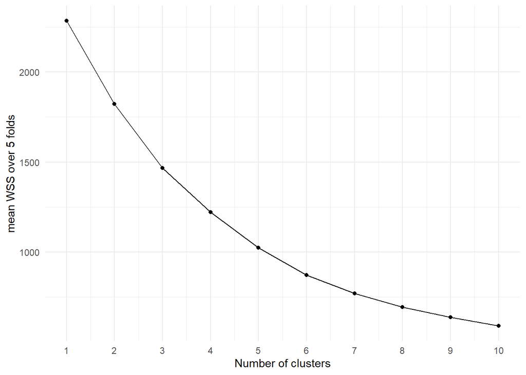

```r
# cluster analysis ----------------------------------------------------

# set a seed because the clusters are not deterministic
set.seed(202304281)

# set up 5 fold cross-validation
transit_cv <- vfold_cv(transit_pca, v = 5)

# create a k-means clustering model spec with num_clusters = tune() for tuning
kmeans_spec <- k_means(
  num_clusters = tune()
) %>%
  set_engine(
    "stats",
    nstart = 100
  )


# create a workflow with the pca_rec recipe and kmeans_spec specification
kmeans_wflow <- workflow(
  preprocessor = pca_rec,
  spec = kmeans_spec
)

# create a tuning grid to consider 1 to 10 clusters
clust_num_grid <- grid_regular(
    num_clusters(),
    levels = 10
  )


# tune the k-means clustering algorithm
res <- tune_cluster(
  object = kmeans_wflow,
  resamples = transit_cv,
  grid = clust_num_grid,
  control = control_grid(save_pred = TRUE, extract = identity),
  metrics = cluster_metric_set(sse_within_total)
)


# collect metrics from tuning the number of clusters and create an elbow plot
# 4 seems roughly the best here
res %>%
  collect_metrics() %>%
  filter(.metric == "sse_within_total") %>%
  ggplot(aes(x = num_clusters, y = mean)) +
  geom_point() +
  geom_line() +
  scale_x_continuous(breaks = 1:10) +
  labs(
    x = "Number of clusters",
    y = "mean WSS over 5 folds"
  ) +
  theme_minimal()
```

Although other metrics suggest that fewer clusters may be optimal, there is no consensus between four, two, and one, and we decide to use four with the understanding that some may be highly similar.

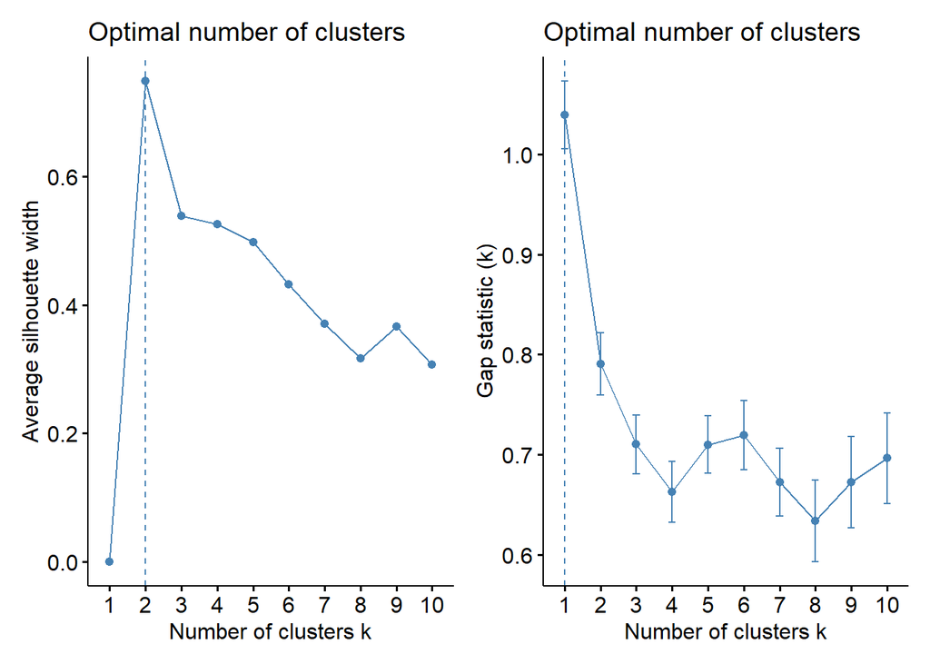

```r
# Set seed
set.seed(202305121)

# Average silhouette width
fv1 <- fviz_nbclust(transit_pca, kmeans, method = "silhouette")

# Gap statistics
fv2 <- fviz_nbclust(transit_pca, kmeans, method = "gap_stat")

fv1 + fv2
```

```r
# final cluster analysis --------------------------------------------------


# we used 5-fold cross-validation to find the ideal number of clusters
# now we need to fit one final model with 4 clusters

# create a k-means specification with num_clusters = 4
kmeans_spec_final <- k_means(
  num_clusters = 4
) %>%
  set_engine(
    "stats",
    nstart = 100
  )


# create the final workflow
kmeans_wflow_final <- workflow(
  preprocessor = pca_rec,
  spec = kmeans_spec_final
)

# fit the final model
final_fit <- fit(
  kmeans_wflow_final,
  data = transit_pca
)

# examine the cluster means
tidy(final_fit)
```

[output not shown]

### Cluster Visualization

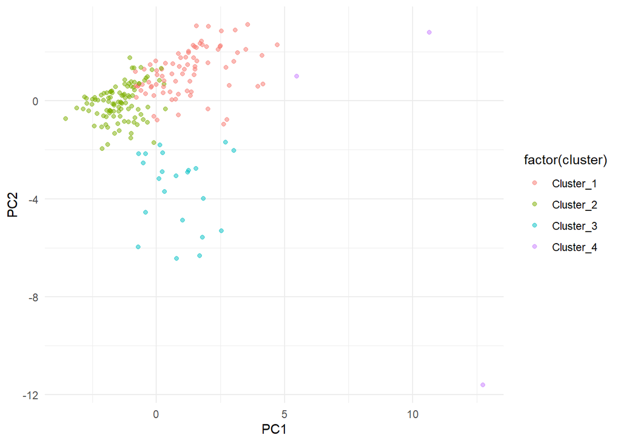

```r
# create a dataframe that binds together the transit, PCA, and cluster data
transit_clusters <- bind_cols(
  transit_original,
  final_fit %>%
    extract_recipe() %>%
    bake(transit_pca),
  cluster = final_fit %>%
    extract_cluster_assignment() %>%
    pull(.cluster)
)

# create a plot of the clusters with PC1 and PC2 as the x and y axis
ggplot() +
  geom_point(
    data = transit_clusters,
    mapping = aes(x = PC1, y = PC2, color = factor(cluster)),
    alpha = 0.5
  ) +
  theme_minimal()
```

To better understand these clusters, we map them, finding that:

1. Cluster one covers downtown, Capitol Hill, and Georgetown.
2. Cluster two is the most geographically dispersed, and it captures all of Wards 7 and 8.
3. Cluster three is intermingled with much of cluster two, but covers more of the northern areas of DC.
4. Cluster four largely represents Haines Point and the National Mall.

```r
# Plot clusters by geography, this chunk is set to results = 'hide'
# to hide the ugly output from sf_transform

dc_tracts <- tracts(state = 11) %>%
  st_transform(crs = 4326) %>%
  clean_names() %>%
  select(geoid)
```

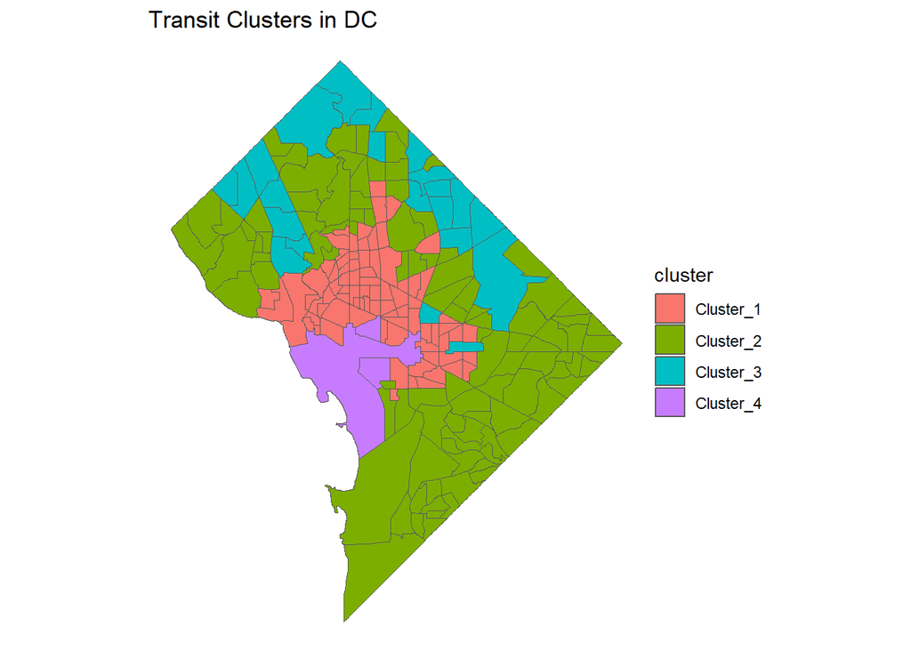

```r
clusters_merge <- merge(transit_clusters, dc_tracts, by = "geoid")

clusters_merge <- clusters_merge %>%
  st_as_sf()

ggplot() +
  geom_sf(data = dc_tracts) +
  geom_sf(data = clusters_merge, aes(fill = cluster)) +
  labs(title = "Transit Clusters in DC") +
  theme_void()
```

We then create a correlation matrix and identify the five most correlated factors with the first and second components. For the first, this includes walking commutes, the number of metro lines, total bike lanes, taxi capacity, and time commuting.

Clusters one and four have more walking, metro, bike lanes, and taxis. Clusters two and three have fewer options and longer commute times.

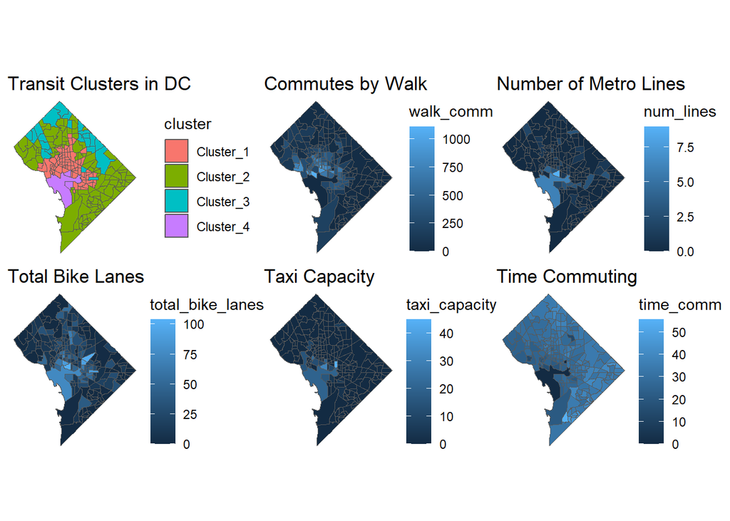

```r
# Maps for the 5 most correlated factors with PC1

cor_matrix <- cor(transit_clusters[sapply(transit_clusters,is.numeric)])


p1 <- ggplot() +
  geom_sf(data = dc_tracts) +
  geom_sf(data = clusters_merge, aes(fill = cluster)) +
  labs(title = "Transit Clusters in DC") +
  theme_void()

p2 <- ggplot() +
  geom_sf(data = dc_tracts) +
  geom_sf(data = clusters_merge, aes(fill = walk_comm)) +
  labs(title = "Commutes by Walk") +
  theme_void()

p3 <- ggplot() +
  geom_sf(data = dc_tracts) +
  geom_sf(data = clusters_merge, aes(fill = num_lines)) +
  labs(title = "Number of Metro Lines") +
  theme_void()

p4 <- ggplot() +
  geom_sf(data = dc_tracts) +
  geom_sf(data = clusters_merge, aes(fill = total_bike_lanes)) +
  labs(title = "Total Bike Lanes") +
  theme_void()

p5 <- ggplot() +
  geom_sf(data = dc_tracts) +
  geom_sf(data = clusters_merge, aes(fill = taxi_capacity)) +
  labs(title = "Taxi Capacity") +
  theme_void()

p6 <- ggplot() +
  geom_sf(data = dc_tracts) +
  geom_sf(data = clusters_merge, aes(fill = time_comm)) +
  labs(title = "Time Commuting") +
  theme_void()


p1 + p2 + p3 + p4 + p5 + p6
```

Now, looking at the second component, there are clearer distinctions between clusters two and three. Relative to cluster three, cluster two has more traffic restrictions and bus stops. Cluster four has a high number of traffic restrictions as well, which makes sense; it is mostly green areas.

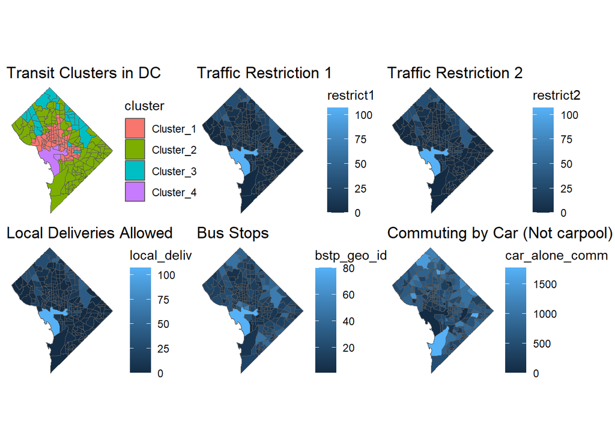

```r
# Maps for the top five most correlated factors with PC2
p1 <- ggplot() +
  geom_sf(data = dc_tracts) +
  geom_sf(data = clusters_merge, aes(fill = cluster)) +
  labs(title = "Transit Clusters in DC") +
  theme_void()

p2 <- ggplot() +
  geom_sf(data = dc_tracts) +
  geom_sf(data = clusters_merge, aes(fill = restrict1 )) +
  labs(title = "Traffic Restriction 1") +
  theme_void()

p3 <- ggplot() +
  geom_sf(data = dc_tracts) +
  geom_sf(data = clusters_merge, aes(fill = restrict2 )) +
  labs(title = "Traffic Restriction 2") +
  theme_void()

p4 <- ggplot() +
  geom_sf(data = dc_tracts) +
  geom_sf(data = clusters_merge, aes(fill = local_deliv)) +
  labs(title = "Local Deliveries Allowed") +
  theme_void()

p5 <- ggplot() +
  geom_sf(data = dc_tracts) +
  geom_sf(data = clusters_merge, aes(fill = bstp_geo_id)) +
  labs(title = "Bus Stops") +
  theme_void()

p6 <- ggplot() +
  geom_sf(data = dc_tracts) +
  geom_sf(data = clusters_merge, aes(fill = car_alone_comm)) +
  labs(title = "Commuting by Car (Not carpool)") +
  theme_void()

p1 + p2 + p3 + p4 + p5 + p6
```

**Cluster one is “More options.”** This cluster may represent census tracts with a uniquely high variety of transportation modes.

**Cluster two is “Fewer options, restricted traffic.”** This cluster may represent census tracts that have fewer transportation modes but restrictions on truck traffic, such as low-transit residential areas. It also has a higher rate of people taking personal cars without carpooling.

**Cluster four is “Intermediate options, restricted traffic.”** This cluster may represent census tracts with some variety of transportation modes–between the first and second/third clusters–but with more restrictions on truck traffic as the green areas surrounding downtown.

### Data Visualization

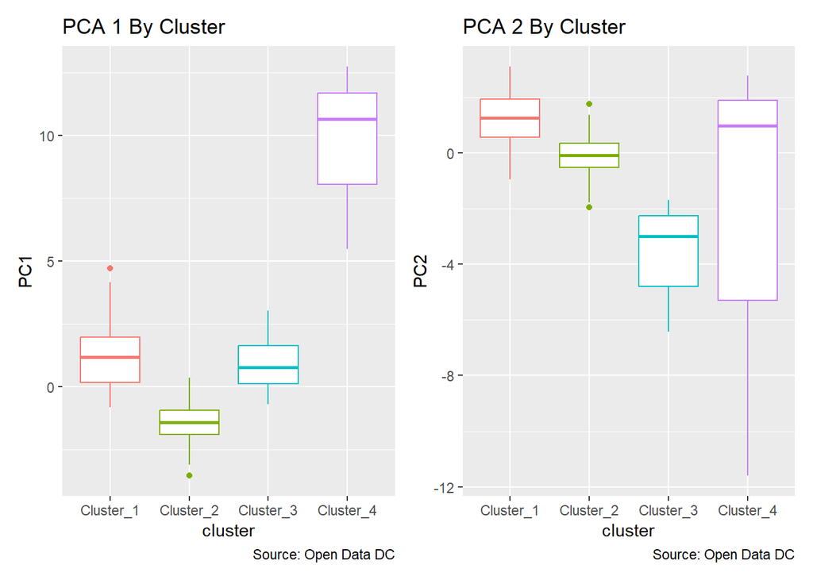

```r
#Bar charts/means

bar1 <- ggplot(data = transit_clusters, aes(x = cluster, y = PC1, color = cluster))+
  geom_boxplot(notch = FALSE)+
  labs(title = "PCA 1 By Cluster",
       caption = "Source: Open Data DC")+
  theme(legend.position = "none")

bar2 <- ggplot(data = transit_clusters, aes(x = cluster, y = PC2, color = cluster))+
  geom_boxplot(notch = FALSE)+
  labs(title = "PCA 2 By Cluster",
       caption = "Source: Open Data DC")+
  theme(legend.position = "none")

bar3 <- ggplot(data = transit_clusters, aes(x = cluster, y = PC3, color = cluster))+
  geom_boxplot(notch = FALSE)+
  labs(title = "PCA 3 By Cluster",
       caption = "Source: Open Data DC")+
  theme(legend.position = "none")

bar4 <- ggplot(data = transit_clusters, aes(x = cluster, y = PC4, color = cluster))+
  geom_boxplot(notch = FALSE)+
  labs(title = "PCA 4 By Cluster",
       caption = "Source: Open Data DC")+
  theme(legend.position = "none")

bar5 <- ggplot(data = transit_clusters, aes(x = cluster, y = PC4, color = cluster))+
  geom_boxplot(notch = FALSE)+
  labs(title = "PCA 5 By Cluster",
       caption = "Source: Open Data DC")+
  theme(legend.position = "none")

bar1 + bar2
```

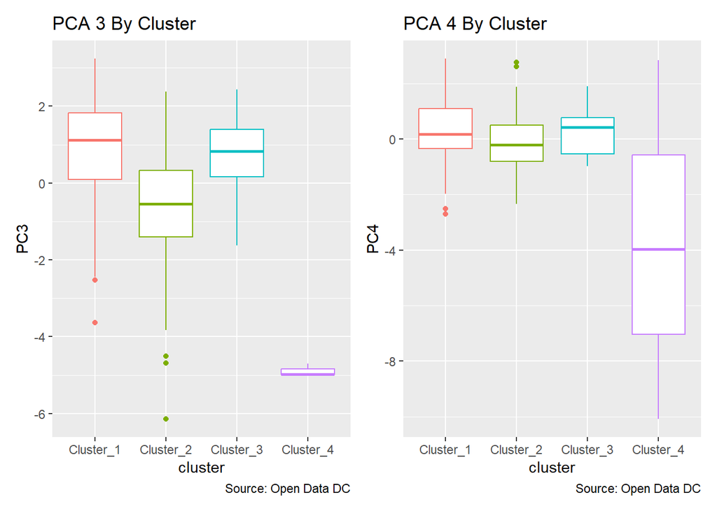

```r
bar3 + bar4
```

[figure not shown]

```r
bar5
```

We then created a basic map of traffic volume to see where it is highest. Unsurprisingly to anyone who’s ever driven a motor vehicle in DC, the downtown areas have exceptionally high traffic volume while the outer reaches of town generally do not, though it is likely that the areas of light blue in the Southeast suburbs traces the lines of major highways like I-95 and 295.

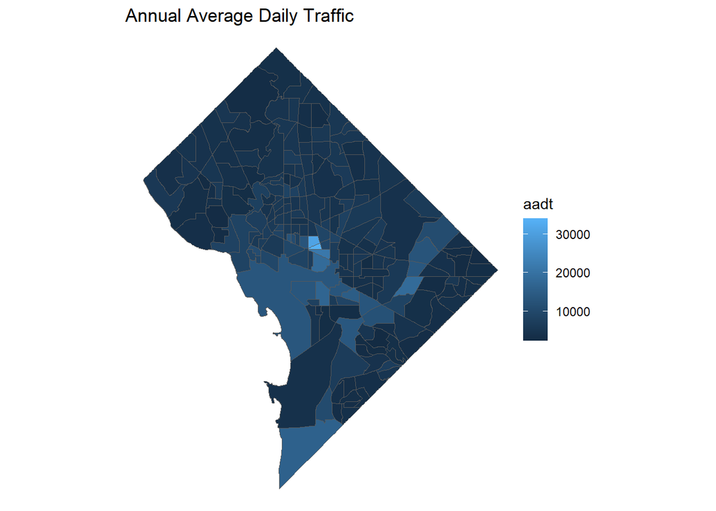

```r
# Overview Graph: Traffic volume
dc <- states(progress_bar = FALSE) %>%
  filter(STUSPS == "DC")

ggplot() +
  geom_sf(data = dc) +
  geom_sf(data = clusters_merge, aes(fill = aadt)) +
  labs(title = "Annual Average Daily Traffic") +
  theme_void()
```

Switching to look solely at public transit availability, we see that this also follows our clusters in broad strokes. The core areas of downtown experience vastly higher availability of multiple public transit modes than the outer reaches.

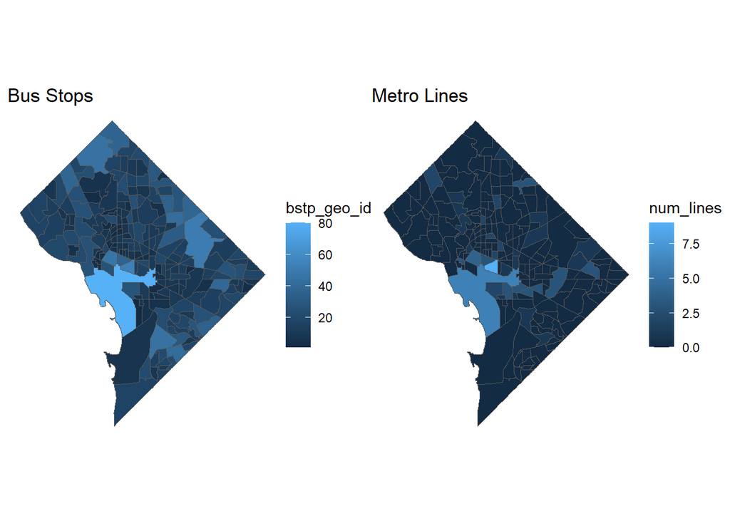

```r
# Summary: Public transit
p1 <- ggplot() +
  geom_sf(data = dc) +
  geom_sf(data = clusters_merge, aes(fill = bstp_geo_id)) +
  labs(title = "Bus Stops") +
  theme_void()

p2 <- ggplot() +
  geom_sf(data = dc) +
  geom_sf(data = clusters_merge, aes(fill = num_lines)) +
  labs(title = "Metro Lines") +
  theme_void()

p1 + p2
```

## Regression Analysis

Our first model regresses PM 2.5 levels on each “transportation typology.” Cluster one is the reference category, represented by the intercept, and is significant at the one percent level. Cluster two is also significant at the one percent level. Because of the overlaps between clusters one and four, and the overlaps between clusters two and three, it makes sense that only one cluster from each pair is significant.

Cluster three (“Fewer options, unrestricted traffic”) has the highest air pollution on average, and cluster two (“Fewer options, restricted traffic”) has the lowest.

```r
# Regression One
model <- lm(pm25 ~ cluster, data=transit_clusters)
summary(model)
```

```
Call:
lm(formula = pm25 ~ cluster, data = transit_clusters)

Residuals:
      Min        1Q    Median        3Q       Max
-0.232126 -0.019541  0.005878  0.027171  0.095369

Coefficients:
                  Estimate Std. Error  t value Pr(>|t|)
(Intercept)       8.644327   0.006970 1240.224  < 2e-16 ***
clusterCluster_2 -0.055079   0.009331   -5.903 1.49e-08 ***
clusterCluster_3  0.007010   0.015008    0.467    0.641
clusterCluster_4 -0.039111   0.036661   -1.067    0.287
---
Signif. codes:  0 '***' 0.001 '**' 0.01 '*' 0.05 '.' 0.1 ' ' 1

Residual standard error: 0.06234 on 202 degrees of freedom
Multiple R-squared:  0.1727,    Adjusted R-squared:  0.1604
F-statistic: 14.05 on 3 and 202 DF,  p-value: 2.35e-08
```

One explanation of the first model’s findings is that the clusters reflect both transit options and different levels of air pollution because of a third variable that is driving these results. In the second model, we introduce variables on race, income, and tree coverage to reduce some of this possible endogeneity. Race and income should somewhat capture the differences in land use, industry, and other factors that are the products of historical, racist policy and planning decisions; these continue to affect transportation equity issues and air quality today. Tree coverage is related, and it may mitigate air pollution even in high-driving areas.

```r
# Regression Two: Control Variables
model <- lm(pm25 ~ cluster + race_black_aa + race_white + race_asian + race_hispanic + poverty_est + utc_pct, data=transit_clusters)
summary(model)
```

```
Call:
lm(formula = pm25 ~ cluster + race_black_aa + race_white + race_asian +
    race_hispanic + poverty_est + utc_pct, data = transit_clusters)

Residuals:
      Min        1Q    Median        3Q       Max
-0.185418 -0.018594  0.002896  0.023561  0.138934

Coefficients:
                   Estimate Std. Error t value Pr(>|t|)
(Intercept)       8.640e+00  9.687e-03 891.907  < 2e-16 ***
clusterCluster_2 -6.671e-03  1.053e-02  -0.633  0.52719
clusterCluster_3  9.705e-03  1.335e-02   0.727  0.46819
clusterCluster_4 -3.648e-02  2.812e-02  -1.298  0.19596
race_black_aa    -1.039e-05  3.476e-06  -2.989  0.00316 **
race_white       -7.517e-06  4.710e-06  -1.596  0.11208
race_asian        1.099e-04  4.227e-05   2.600  0.01004 *
race_hispanic     2.203e-03  4.669e-04   4.718 4.52e-06 ***
poverty_est      -2.296e-03  3.417e-04  -6.720 1.93e-10 ***
utc_pct           1.351e-04  3.401e-04   0.397  0.69168
---
Signif. codes:  0 '***' 0.001 '**' 0.01 '*' 0.05 '.' 0.1 ' ' 1

Residual standard error: 0.04713 on 196 degrees of freedom
Multiple R-squared:  0.5411,    Adjusted R-squared:  0.5201
F-statistic: 25.68 on 9 and 196 DF,  p-value: < 2.2e-16
```

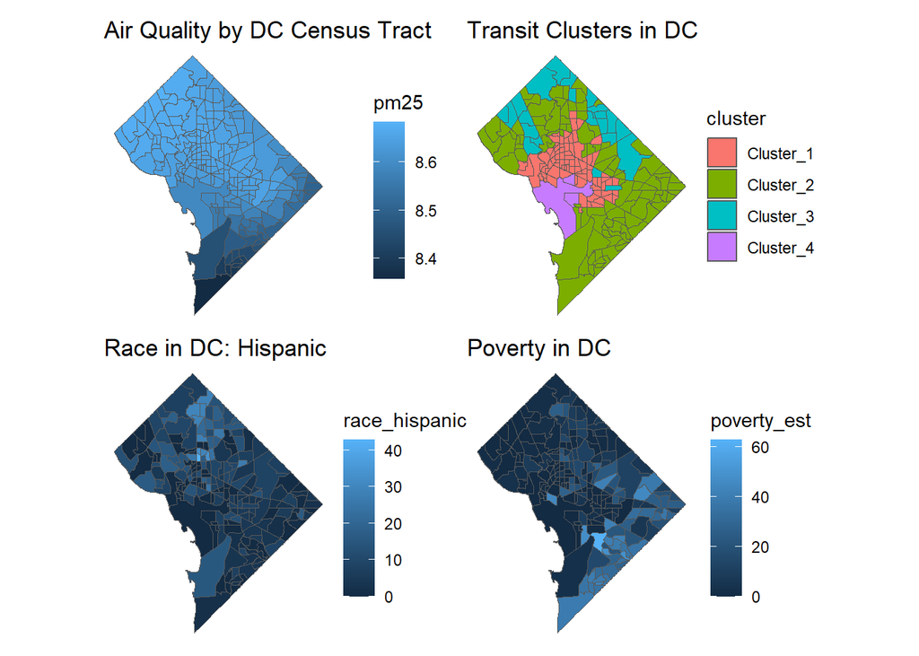

```r
# Visualization
p1 <- ggplot() +
  geom_sf(data = dc_tracts) +
  geom_sf(data = clusters_merge, aes(fill = pm25 )) +
  labs(title = "Air Quality by DC Census Tract") +
  theme_void()

p2 <- ggplot() +
  geom_sf(data = dc_tracts) +
  geom_sf(data = clusters_merge, aes(fill = cluster)) +
  labs(title = "Transit Clusters in DC") +
  theme_void()

p3 <- ggplot() +
  geom_sf(data = dc_tracts) +
  geom_sf(data = clusters_merge, aes(fill = race_hispanic)) +
  labs(title = "Race in DC: Hispanic") +
  theme_void()

p4 <- ggplot() +
  geom_sf(data = dc_tracts) +
  geom_sf(data = clusters_merge, aes(fill = poverty_est)) +
  labs(title = "Poverty in DC") +
  theme_void()

p1 + p2 + p3 + p4
```

In the third regression, we use all of the numeric variables we have as covariates, aiming to identify some of the specific transportation characteristics that may be making the first cluster significant. The factors that are most significantly associated with reductions in PM 2.5 are bus stops with bike racks, commuting by walking, and lower traffic volume.

```r
# Regression Three: All numeric variables
transit_numeric <- select_if(transit_clusters, is.numeric)

model <- lm(pm25 ~ ., data = transit_numeric)
summary(model)
```

```
Call:
lm(formula = pm25 ~ ., data = transit_numeric)

Residuals:
      Min        1Q    Median        3Q       Max
-0.126031 -0.019655  0.000327  0.022056  0.105138

Coefficients: (7 not defined because of singularities)
                              Estimate Std. Error t value Pr(>|t|)
(Intercept)                  1.616e+03  7.343e+02   2.200 0.029111 *
geoid                       -1.461e-07  6.675e-08  -2.188 0.029977 *
num_lines                   -4.032e-03  4.281e-03  -0.942 0.347545
bstp_has_bkrs               -1.272e-01  3.432e-02  -3.707 0.000281 ***
shelter                      4.880e-02  1.908e-02   2.558 0.011391 *
bstp_bnh_cnt                -5.541e-02  2.364e-02  -2.344 0.020193 *
school_stop                         NA         NA      NA       NA
bstp_geo_id                 -5.915e-04  4.561e-04  -1.297 0.196365
aadt                         3.985e-06  9.986e-07   3.990 9.69e-05 ***
transit_comm                 1.977e-05  1.323e-05   1.494 0.136896
walk_comm                   -8.845e-05  2.243e-05  -3.944 0.000116 ***
time_comm                   -1.708e-03  6.890e-04  -2.479 0.014129 *
car_alone_comm               2.455e-06  1.521e-05   0.161 0.871959
carpool_comm                 7.658e-05  5.159e-05   1.485 0.139474
total_bike_lanes             4.170e-04  1.927e-04   2.164 0.031797 *
bikelane_protected           3.050e-02  3.138e-02   0.972 0.332491
bikelane_dual_protected      3.944e-02  2.092e-02   1.885 0.061107 .
shared_mobility             -7.957e-04  1.008e-03  -0.789 0.431155
taxi_capacity                4.169e-04  8.041e-04   0.518 0.604833
limo_capacity               -2.819e-03  7.139e-03  -0.395 0.693414
restrict1                    1.427e-02  1.390e-02   1.027 0.305719
restrict2                           NA         NA      NA       NA
local_deliv                 -1.372e-02  1.391e-02  -0.986 0.325632
density_score               -8.262e-02  3.346e-02  -2.469 0.014518 *
four_way_intersection_ratio  1.364e-03  4.309e-02   0.032 0.974789
sidewalk_score              -8.978e-01  3.914e-01  -2.294 0.023000 *
pfi_score                    1.128e-01  2.465e-02   4.575 8.99e-06 ***
poverty_est                 -1.894e-03  3.465e-04  -5.466 1.56e-07 ***
race_white                  -6.883e-06  4.607e-06  -1.494 0.136953
race_black_aa               -6.080e-06  4.411e-06  -1.378 0.169887
race_asian                   1.183e-04  4.420e-05   2.675 0.008172 **
race_hispanic                1.324e-03  4.558e-04   2.906 0.004139 **
utc_pct                      4.086e-04  3.727e-04   1.096 0.274557
PC1                                 NA         NA      NA       NA
PC2                                 NA         NA      NA       NA
PC3                                 NA         NA      NA       NA
PC4                                 NA         NA      NA       NA
PC5                                 NA         NA      NA       NA
---
Signif. codes:  0 '***' 0.001 '**' 0.01 '*' 0.05 '.' 0.1 ' ' 1

Residual standard error: 0.04158 on 175 degrees of freedom
Multiple R-squared:  0.6811,    Adjusted R-squared:  0.6264
F-statistic: 12.46 on 30 and 175 DF,  p-value: < 2.2e-16
```

## Exploring Air Quality in DC

Transportation is not the only determinant of air quality in the District, and PM 2.5 is not the only pollutant. DC has air quality monitors that track more data, including over time, than the EJ Screen data. Although we could not use this in the cluster analysis because the monitors are only in five census tracts, the data are nevertheless useful for providing important context for our results.

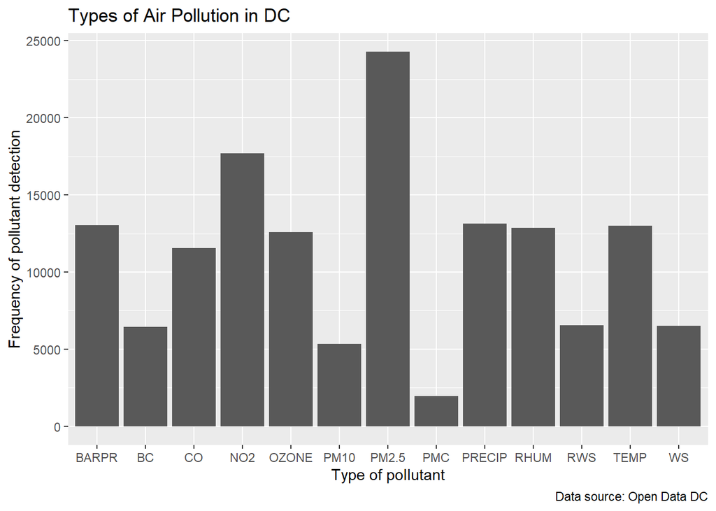

```r
air_monitors <- read_csv("data/Air_Quality_Realtime.csv")

air_monitors <- air_monitors %>%
  janitor::clean_names() %>%
  mutate(datetime_clean = ymd_hms(datetime_local))%>%
  mutate(year = year(datetime_clean))%>%
  mutate(day = wday(datetime_clean, label = FALSE))%>%
  mutate(month = month(datetime_clean, label = FALSE))%>%
  mutate(time = hour(datetime_clean))%>%
  select(-datasource, -objectid, -aqsid, -datetime_local, -datetime_clean)%>%
  drop_na()

airqual_split <- initial_split(data = air_monitors)

airqual_train <- training(x = airqual_split)
airqual_test <- testing(x = airqual_split)

#visualization 1
airqual_train %>%
  group_by(parametername)%>%
  ggplot() +
  geom_bar(mapping = aes(x = parametername))+
  labs(title = "Types of Air Pollution in DC",
       caption = "Data source: Open Data DC",
       )+
  xlab("Type of pollutant")+
  ylab("Frequency of pollutant detection")
```

See below for the mean values of each type of pollution shown in the overview chart.

```r
#mean values for each type of pollution

airqual_train %>%
 group_by(parametername)%>%
  summarize(average_value = mean(value))
```

```
# A tibble: 13 × 2
   parametername average_value
   <chr>                 <dbl>
 1 BARPR             1013.
 2 BC                   0.389
 3 CO                   0.369
 4 NO2                 11.3
 5 OZONE               26.1
 6 PM10                16.1
 7 PM2.5                7.72
 8 PMC                  7.36
 9 PRECIP               0.0372
10 RHUM                62.0
11 RWS                  2.76
12 TEMP                15.8
13 WS                   6.50
```

As expected from our regression analysis, air pollution does vary spatially. Each of the air monitors detects different levels of each pollutant–not just PM 2.5. An example of variation in NO2 pollution across the air monitors is below.

```r
#NO2
airqual_train %>%
 filter(parametername == "NO2")%>%
  group_by(sitename)%>%
  count()
```

```
# A tibble: 4 × 2
# Groups:   sitename [4]
  sitename               n
  <chr>              <int>
1 DCNearRoad          6284
2 McMillan Reservoir  5804
3 RIVER_Terrace       2501
4 TakomaRec           3121
```

```r
ungroup(airqual_train)
```

```
# A tibble: 145,005 × 8
   sitename          parametername reportingunits  value  year   day month  time
   <chr>             <chr>         <chr>           <dbl> <dbl> <dbl> <dbl> <int>
 1 McMillan Reservo… BARPR         MILLIBAR       1017.   2023     1     3    18
 2 DCNearRoad        TEMP          C                 2    2023     3     3     6
 3 DCNearRoad        RWS           KNOTS             2.2  2022     1     6    13
 4 DCNearRoad        BARPR         MILLIBAR       1013.   2022     5     8     8
 5 McMillan Reservo… PMC           UG/M3            35    2022     4    11     8
 6 McMillan Reservo… NO2           PPB              31.1  2023     5     1    10
 7 RIVER_Terrace     OZONE         PPB              22    2022     5     6     8
 8 McMillan Reservo… PMC           UG/M3             0    2022     1    11    18
 9 McMillan Reservo… RHUM          PERCENT          88.7  2022     1     8    20
10 McMillan Reservo… PRECIP        MM                0    2022     6     7    13
# ℹ 144,995 more rows
```

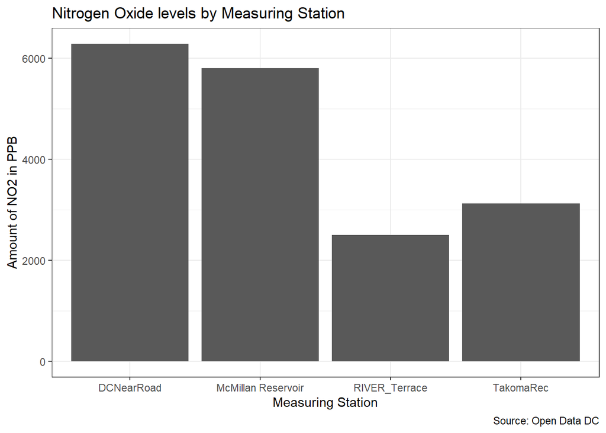

```r
#Visualization 2
airqual_train %>%
  filter(parametername == "NO2")%>%
  group_by(sitename)%>%
  ggplot()+
  geom_bar(mapping= aes(x = sitename))+
  labs(title = "Nitrogen Oxide levels by Measuring Station",
       x = "Measuring Station",
       y = "Amount of NO2 in PPB",
       caption = "Source: Open Data DC")+
  theme_bw()
```

```r
ungroup(airqual_train)
```

```
# A tibble: 145,005 × 8
   sitename          parametername reportingunits  value  year   day month  time
   <chr>             <chr>         <chr>           <dbl> <dbl> <dbl> <dbl> <int>
 1 McMillan Reservo… BARPR         MILLIBAR       1017.   2023     1     3    18
 2 DCNearRoad        TEMP          C                 2    2023     3     3     6
 3 DCNearRoad        RWS           KNOTS             2.2  2022     1     6    13
 4 DCNearRoad        BARPR         MILLIBAR       1013.   2022     5     8     8
 5 McMillan Reservo… PMC           UG/M3            35    2022     4    11     8
 6 McMillan Reservo… NO2           PPB              31.1  2023     5     1    10
 7 RIVER_Terrace     OZONE         PPB              22    2022     5     6     8
 8 McMillan Reservo… PMC           UG/M3             0    2022     1    11    18
 9 McMillan Reservo… RHUM          PERCENT          88.7  2022     1     8    20
10 McMillan Reservo… PRECIP        MM                0    2022     6     7    13
# ℹ 144,995 more rows
```

Moreover, air pollution varies over time–something we were not able to test with the 2017 data. For example, ozone levels drop throughout the first third of the year before increasing again, and are typically highest in December.

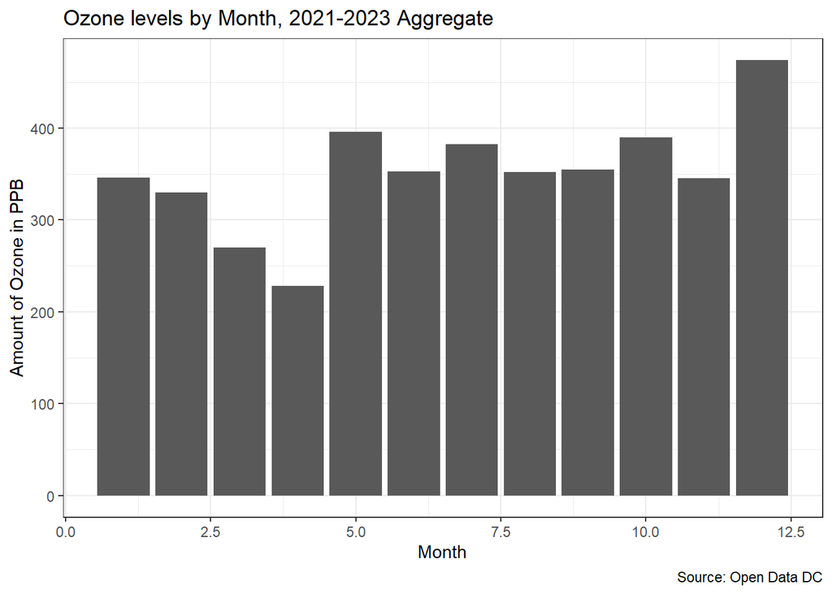

```r
#Visualization 3
airqual_train %>%
  filter(parametername == "OZONE", year == c("2021", "2022", "2023"))%>%
  ggplot()+
  geom_bar(mapping = aes(x = month))+
  labs(title = "Ozone levels by Month, 2021-2023 Aggregate",
       x = "Month",
       y = "Amount of Ozone in PPB",
       caption = "Source: Open Data DC")+
  theme_bw()
```

PM 2.5 levels also vary by month and are lowest in January and February. If this data is tracked in each census tract in the future, it would be interesting to know whether these time trends are the same across each “transit typology.”

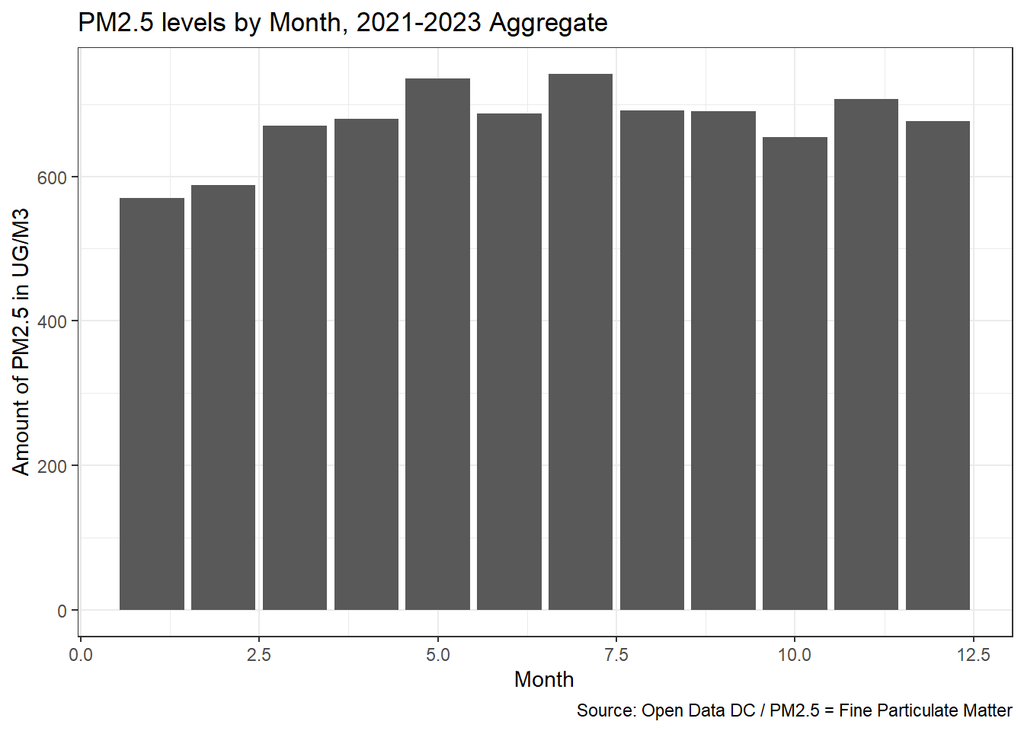

```r
#Visualization 4
airqual_train %>%
  filter(parametername == "PM2.5", year == c("2021", "2022", "2023"))%>%
  ggplot()+
  geom_bar(mapping = aes(x = month))+
  labs(title = "PM2.5 levels by Month, 2021-2023 Aggregate",
       x = "Month",
       y = "Amount of PM2.5 in UG/M3",
       caption = "Source: Open Data DC / PM2.5 = Fine Particulate Matter")+
  theme_bw()
```

## Decision Tree

Finally, we create a decision tree that categorizes air monitor observations. We decided to focus on a single pollutant, Fine Particulate Matter (PM2.5), which is measured at every monitoring station and which stuck out to us in the very first bar graph as being much higher than the other pollutants. Burning fuels, whether it be in a power plant or the engine of a car, generates PM2.5 when gases from the nitrogen oxide family interact with the air. These gases and the particulates they produce can, over long periods of exposure, cause or worsen breathing difficulties in children. This is why it’s important to have an accurate understanding of whether location plays a significant role in concentrations of PM2.5 as it may have a negative impact on kids living nearby even if measured quantities are not high-dosage.

All of that being said, our decision tree model’s root mean squared error is on the higher side, indicating that the model needs further refinements. One of the most useful refinements possible would be to add tract-based air monitoring data so we can have a larger sample size for the number of sites we’re monitoring. It would also be ideal if we could add in data from monitoring sites in Maryland and Virginia to ascertain how DC levels compare to surrounding areas. Both of these improvements would be costly financially and in terms of time, though, so it is understandable that they have not been implemented yet.

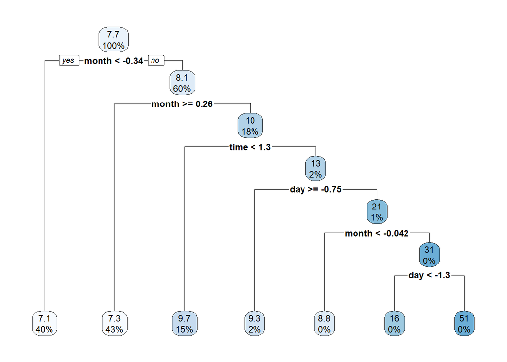

```r
set.seed(123)


airqual_train <- airqual_train%>%
  filter(parametername == "PM2.5")%>%
  select(-parametername, -reportingunits)

airqual_test <- airqual_test%>%
  filter(parametername == "PM2.5")%>%
  select(-parametername, -reportingunits)

airqual_trec <- recipe(value ~ ., data = airqual_train) %>%
  step_normalize(all_numeric_predictors())%>%
  step_dummy(sitename)%>%
  prep()

#regression
airqual_treemod <- decision_tree()%>%
  set_engine(engine = "rpart")%>%
  set_mode(mode = "regression")

airqual_twf <- workflow()%>%
  add_recipe(airqual_trec)%>%
  add_model(airqual_treemod)

airqual_fit <- airqual_twf%>%
  fit(data = airqual_train)

rpart.plot::rpart.plot(x = airqual_fit$fit$fit$fit)
```

```r
airqual_trpredict <- bind_cols(
  airqual_test,
  predict(object = airqual_fit, new_data = airqual_test)
)

airqual_trpredict%>%
  rmse(value, .pred)%>%
  print()
```

```
# A tibble: 1 × 3
  .metric .estimator .estimate
  <chr>   <chr>          <dbl>
1 rmse    standard        5.82
```

## Recommendations and Conclusions

Our cluster analysis demonstrated how patterns of transportation relate to air quality. From there, our deeper dive into air quality in DC revealed several limitations with our original analysis. We recommend that the city collect air quality data covering multiple pollutants across each census tract. This would enable future researchers to investigate whether certain “transportation typologies” have different air quality patterns throughout the year, whether the typologies are associated with different pollutants, and create a decision tree that incorporates these transportation-related insights.

With this information, local policymakers could better target interventions to improve air quality through the transportation system, such as updating restrictions on truck traffic, increasing the transit options serving wards outside of the downtown area, and incentivizing non-car commutes.